# Machine Learning

## Indah Agustien Siradjuddin

## Artificial Neural Networks

Semester Gasal 2019-2020

## *Single layer Perceptron*

*Single layer Perceptron* / *Perceptron* : untuk data yang dapat dipisahkan secara linear, *linearly separable data*, bukan *unlinearly separable data*, seperti data logika XOR e.g. logical data XOR

```python
import numpy as np
import matplotlib.pyplot as matPlot
#inisialisasi data
data=np.array([[1,1,1],[1,1,0],[1,0,1],[1,0,0]]) # bias dan data
targetAnd=np.array([1,0,0,0])
targetOr=np.array([1,1,1,0])
targetXor=np.array([0,1,1,0])
```

### *Linearly Separable Data*

```python
import perceptron
```

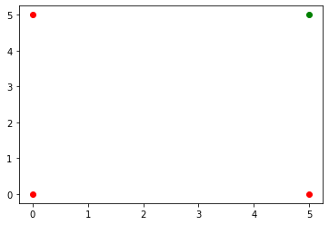

```python
perceptron.plotting(data,targetAnd)
```

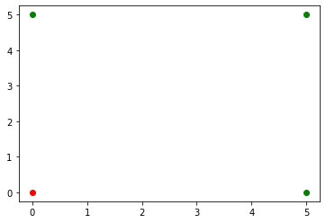

```python
perceptron.plotting(data,targetOr)
```

## *Unlinearly Separable Data*

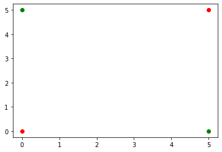

```python
perceptron.plotting(data,targetXor)
```

## *Multilayer Perceptron*

Berdasarkan grafik data XOR, maka dibutuhkan lebih dari satu garis untuk memisahkan data XOR.  
Logika XOR dapat juga didefinisikan sebagai berikut :

$x_1$ XOR $x_2$ = ($x_1$ AND (NOT $x_2$)) OR ($x_2$ AND (NOT $x_1$))

### Latihan :

1. Dengan menggunakan tabel kebenaran, buktikan ekivalensi logika XOR tersebut
2. Buat Model XOR dengan menggunakan code perceptron

```python
import numpy as np
import matplotlib.pyplot as matPlot
#inisialisasi data
data=np.array([[1,1,1],[1,1,0],[1,0,1],[1,0,0]]) # bias dan data
targetAndNot1=np.array([0,1,0,0])
targetAndNot2=np.array([0,0,1,0])
targetOr=np.array([1,1,1,0])
```

```python
import perceptron
```

```python
w=perceptron.perceptronLearning(data,targetAndNot1)
```

```
data= [[1 1 1]
 [1 1 0]
 [1 0 1]
 [1 0 0]]
target= [0 1 0 0]
bobot= [[0.1]
 [0.2]
 [0.3]]
bobot= [[0.1]
 [0.2]
 [0.3]]
jumlah epoch5
epoch =  0 : [[ 0.1 -0.9  0.1  0.1 -0.9]
 [ 0.2 -0.8  0.2  0.2  0.2]
 [ 0.3 -0.7 -0.7 -0.7 -0.7]]
epoch =  1 : [[ 0.1 -0.9  0.1  0.1 -0.9 -0.9  0.1  0.1 -0.9]
 [ 0.2 -0.8  0.2  0.2  0.2  0.2  1.2  1.2  1.2]
 [ 0.3 -0.7 -0.7 -0.7 -0.7 -0.7 -0.7 -0.7 -0.7]]
epoch =  2 : [[ 0.1 -0.9  0.1  0.1 -0.9 -0.9  0.1  0.1 -0.9 -0.9 -0.9 -0.9 -0.9]
 [ 0.2 -0.8  0.2  0.2  0.2  0.2  1.2  1.2  1.2  1.2  1.2  1.2  1.2]
 [ 0.3 -0.7 -0.7 -0.7 -0.7 -0.7 -0.7 -0.7 -0.7 -0.7 -0.7 -0.7 -0.7]]
epoch =  3 : [[ 0.1 -0.9  0.1  0.1 -0.9 -0.9  0.1  0.1 -0.9 -0.9 -0.9 -0.9 -0.9 -0.9
  -0.9 -0.9 -0.9]
 [ 0.2 -0.8  0.2  0.2  0.2  0.2  1.2  1.2  1.2  1.2  1.2  1.2  1.2  1.2
   1.2  1.2  1.2]
 [ 0.3 -0.7 -0.7 -0.7 -0.7 -0.7 -0.7 -0.7 -0.7 -0.7 -0.7 -0.7 -0.7 -0.7
  -0.7 -0.7 -0.7]]
epoch =  4 : [[ 0.1 -0.9  0.1  0.1 -0.9 -0.9  0.1  0.1 -0.9 -0.9 -0.9 -0.9 -0.9 -0.9
  -0.9 -0.9 -0.9 -0.9 -0.9 -0.9 -0.9]
 [ 0.2 -0.8  0.2  0.2  0.2  0.2  1.2  1.2  1.2  1.2  1.2  1.2  1.2  1.2
   1.2  1.2  1.2  1.2  1.2  1.2  1.2]
 [ 0.3 -0.7 -0.7 -0.7 -0.7 -0.7 -0.7 -0.7 -0.7 -0.7 -0.7 -0.7 -0.7 -0.7
  -0.7 -0.7 -0.7 -0.7 -0.7 -0.7 -0.7]]
```

```python
w1=w[:,-1]
print('w and not 1=',w1)
```

```
w and not 1= [-0.9  1.2 -0.7]
```

```python
w=perceptron.perceptronLearning(data,targetAndNot2)
```

```
data= [[1 1 1]
 [1 1 0]
 [1 0 1]
 [1 0 0]]
target= [0 0 1 0]
bobot= [[0.1]
 [0.2]
 [0.3]]
bobot= [[0.1]
 [0.2]
 [0.3]]
jumlah epoch5
epoch =  0 : [[ 0.1 -0.9 -0.9  0.1 -0.9]
 [ 0.2 -0.8 -0.8 -0.8 -0.8]
 [ 0.3 -0.7 -0.7  0.3  0.3]]
epoch =  1 : [[ 0.1 -0.9 -0.9  0.1 -0.9 -0.9 -0.9  0.1 -0.9]
 [ 0.2 -0.8 -0.8 -0.8 -0.8 -0.8 -0.8 -0.8 -0.8]
 [ 0.3 -0.7 -0.7  0.3  0.3  0.3  0.3  1.3  1.3]]
epoch =  2 : [[ 0.1 -0.9 -0.9  0.1 -0.9 -0.9 -0.9  0.1 -0.9 -0.9 -0.9 -0.9 -0.9]
 [ 0.2 -0.8 -0.8 -0.8 -0.8 -0.8 -0.8 -0.8 -0.8 -0.8 -0.8 -0.8 -0.8]
 [ 0.3 -0.7 -0.7  0.3  0.3  0.3  0.3  1.3  1.3  1.3  1.3  1.3  1.3]]
epoch =  3 : [[ 0.1 -0.9 -0.9  0.1 -0.9 -0.9 -0.9  0.1 -0.9 -0.9 -0.9 -0.9 -0.9 -0.9
  -0.9 -0.9 -0.9]
 [ 0.2 -0.8 -0.8 -0.8 -0.8 -0.8 -0.8 -0.8 -0.8 -0.8 -0.8 -0.8 -0.8 -0.8
  -0.8 -0.8 -0.8]
 [ 0.3 -0.7 -0.7  0.3  0.3  0.3  0.3  1.3  1.3  1.3  1.3  1.3  1.3  1.3
   1.3  1.3  1.3]]
epoch =  4 : [[ 0.1 -0.9 -0.9  0.1 -0.9 -0.9 -0.9  0.1 -0.9 -0.9 -0.9 -0.9 -0.9 -0.9
  -0.9 -0.9 -0.9 -0.9 -0.9 -0.9 -0.9]
 [ 0.2 -0.8 -0.8 -0.8 -0.8 -0.8 -0.8 -0.8 -0.8 -0.8 -0.8 -0.8 -0.8 -0.8
  -0.8 -0.8 -0.8 -0.8 -0.8 -0.8 -0.8]
 [ 0.3 -0.7 -0.7  0.3  0.3  0.3  0.3  1.3  1.3  1.3  1.3  1.3  1.3  1.3
   1.3  1.3  1.3  1.3  1.3  1.3  1.3]]
```

```python
w2=w[:,-1]
print('w and not 2=',w2)
```

```
w and not 2= [-0.9 -0.8  1.3]
```

```python
w=perceptron.perceptronLearning(data,targetOr)
```

```
data= [[1 1 1]
 [1 1 0]
 [1 0 1]
 [1 0 0]]
target= [1 1 1 0]
bobot= [[0.1]
 [0.2]
 [0.3]]
bobot= [[0.1]
 [0.2]
 [0.3]]
jumlah epoch5
epoch =  0 : [[ 0.1  0.1  0.1  0.1 -0.9]
 [ 0.2  0.2  0.2  0.2  0.2]
 [ 0.3  0.3  0.3  0.3  0.3]]
epoch =  1 : [[ 0.1  0.1  0.1  0.1 -0.9  0.1  0.1  0.1 -0.9]
 [ 0.2  0.2  0.2  0.2  0.2  1.2  1.2  1.2  1.2]
 [ 0.3  0.3  0.3  0.3  0.3  1.3  1.3  1.3  1.3]]
epoch =  2 : [[ 0.1  0.1  0.1  0.1 -0.9  0.1  0.1  0.1 -0.9 -0.9 -0.9 -0.9 -0.9]
 [ 0.2  0.2  0.2  0.2  0.2  1.2  1.2  1.2  1.2  1.2  1.2  1.2  1.2]
 [ 0.3  0.3  0.3  0.3  0.3  1.3  1.3  1.3  1.3  1.3  1.3  1.3  1.3]]
epoch =  3 : [[ 0.1  0.1  0.1  0.1 -0.9  0.1  0.1  0.1 -0.9 -0.9 -0.9 -0.9 -0.9 -0.9
  -0.9 -0.9 -0.9]
 [ 0.2  0.2  0.2  0.2  0.2  1.2  1.2  1.2  1.2  1.2  1.2  1.2  1.2  1.2
   1.2  1.2  1.2]
 [ 0.3  0.3  0.3  0.3  0.3  1.3  1.3  1.3  1.3  1.3  1.3  1.3  1.3  1.3
   1.3  1.3  1.3]]
epoch =  4 : [[ 0.1  0.1  0.1  0.1 -0.9  0.1  0.1  0.1 -0.9 -0.9 -0.9 -0.9 -0.9 -0.9
  -0.9 -0.9 -0.9 -0.9 -0.9 -0.9 -0.9]
 [ 0.2  0.2  0.2  0.2  0.2  1.2  1.2  1.2  1.2  1.2  1.2  1.2  1.2  1.2
   1.2  1.2  1.2  1.2  1.2  1.2  1.2]
 [ 0.3  0.3  0.3  0.3  0.3  1.3  1.3  1.3  1.3  1.3  1.3  1.3  1.3  1.3
   1.3  1.3  1.3  1.3  1.3  1.3  1.3]]
```

```python
w3=w[:,-1]
print('w or =',w3)
```

```
w or = [-0.9  1.2  1.3]
```

### Learning/Training

*Learning/Training* adalah proses untuk membangun sebuah model, yaitu arsitektur dan bobotnya (*weights*), termasuk bias, dengan menggunakan dataset pelatihan/pembelajaran.  
Jenis Pembelajaran :

1. Supervised learning : data pelatihan (input/feature dan target). Target data yang berperan sebagai 'pengawas', dengan cara memperbaharui bobot (dan bias) dengan tujuan meminimalkan error antara target (output yang diinginkan) dengan output yang sebenarnya.
2. Unsupervised learning : data pelatihan hanya terdiri dari data input/feature saja
3. Reinforcement learning : mekanisme *reward* and *punishment*

### Aturan Pembelajaran

Bobot di-*update* dengan cara meminimalkan error antara target dengan output yang sebenarnya

#### Gradient Descent Learning Rule

Fungsi Error : *Sum Squared Error*

\begin{equation*} E=\sum_{p=1}^{n}(t_p-y_p)^2 \end{equation*}

Dimana :

- $t_i$ : target/output yang diinginkan dari input data-$i$
- $y_i$ : output yang sebenarnya dari input data-$i$
- $n$ : jumlah data pelatihan

Gradient descent untuk meminimalkan error :

[figure not shown]

Sumber :

Sebagaimana yang terdapat pada algoritma perceptron-3, bobot di-*update* dengan menggunakan :  
$w_i(t+1)=w_i(t)+ \Delta x_i(t)$, dimana $\Delta$ adalah selisih antara target dengan output.  
Pada *Gradient Descent Learning*, bobot di-*update* dengan menggunakan persamaan berikut:

\begin{eqnarray} \Delta x_i(t)&=&\eta \big(-\frac{\partial E}{\partial w_i}\big) \\ \frac{\partial E}{\partial w_i}&=&-2(t_p-y_p)\frac{\partial f}{\partial net_p}x_{i,p} \end{eqnarray}

dimana :

- $\eta$ adalah **learning rate**

Akan tetapi, turunan dari fungsi aktivasi sangat sulit didapatkan jika fungsi aktivasi berbentuk diskontinyu, seperti fungsi *ramp* dan *stepwise*.

#### Widrow Hoff Learning Rule

Aturan pembelajaran juga sering disebut sebagai *Least Mean Square* (LMS). Aturan ini digunakan untuk fungsi aktivasi diskontinyu, dengan asumsi $f=net_p$. Oleh karena itu turunan dari fungsi tersebut adalah $\frac{\delta f}{\delta net_p}$ is 1.

\begin{equation*} \frac{\partial E}{\partial w_i}=-2(t_p-y_p)x_{i,p} \end{equation*}

Bobot di-*update* berdasarkan persamaan berikut: \begin{equation*} w_i(t+1)=w_i(t)+2\eta(t_p-y_p)x_{i,p} \end{equation*}

### *Updating Weights*

1. Stochastic/online Learning : setiap iterasi
2. Batch/offline learning : setiap epoch

## Backpropagation

MLP yang sering digunakan berdasarkan algoritma pembelajaran supervised dengan aturan Gradient Descent adalah **Backpropagation Neural Network**. Tahapan *Backpropagation*.:

1. **Feedforward Pass**, menghitung semua output pada semua neuron di setiap *layer*
2. **Backward Propagation**, error (selisih antara target dan output) dikirim kembali dari output layer ke input layer, sehingga setiap bobot dapat di-update

[figure not shown]

   Sumber :
- neuron pada layer input $x_0,x_1,...,x_i $, dimana jumlah neuron (fitur) adalah $d$
- neuron pada hidden layer $y_0,y_1,...,y_j $, dimana jumlah neuron pada hidden layer adalah $j$
- neuron pada output layer $O_0,O_1,...,O_k$, dimana jumlah neuron pada output layer adalah $k$
- $w_{ij}$ bobot antara neuron pada input layer $x_i$ dan neuron pada hidden layer $y_j$
- $v_{jk}$ bobot antara neuron pada hidden layer $y_j$ dan neuron pada output layer $O_k$

Data Iris:

[figure not shown]

Bobot antara input dan hidden layer :

[figure not shown]

Bobot antara hidden dan output layer

[figure not shown]

### Feedforward Pass

Output neuron pada hidden dan output layer dihitung berdasarkan fungsi aktivasi (sigmoid):

\begin{eqnarray} y_j &=& f_{yj}(net_{yj})\\ & =& \frac{1}{1+e^{-net_{yj}}}\\ O_k &=& f_{Ok}(net_{Ok})\\ & =& \frac{1}{1+e^{-net_{Ok}}} \end{eqnarray}

dimana \begin{eqnarray} net_{yj} &=& \sum_{i=0}^{d}(x_iw_{ij})\\ net_{Ok} &=& \sum_{j=0}^{J}(y_jv_{jk}) \end{eqnarray}

- $y_j$ adalah output atau nilai aktivasi dari neuron pada hidden layer
- $O_k$ adalah output atau nilai aktivasi dari neuron pada output layer

**Neuron Hidden Layer**  
**Net input**

\begin{eqnarray*} net_{yj} &=& \sum_{i=0}^{4}(x_iw_{ij}) \\ net_{y1}&=&x_0 \times w_{01}+x_1 \times w_{11}+x2_ \times w_{21}+x_3 \times w_{w31}+x_4 \times w_{41}\\ &=&1 \times 0.1+ 5.1\times 0.2 +3.5 \times 0.1+ 1.4 \times 0.15 +0.2 \times 0.2=1.72\\ net_{y2}&=&x_0 \times w_{02}+x_1 \times w_{12}+x2_ \times w_{22}+x_3 \times w_{w32}+x_4 \times w_{42}\\ &=&1 \times 0.3+ 5.1\times 0.4 +3.5 \times 0.1+ 1.4 \times 0.3 +0.2 \times 0.2=3.15\\ net_{y3}&=&x_0 \times w_{03}+x_1 \times w_{13}+x2_ \times w_{23}+x_3 \times w_{w33}+x_4 \times w_{43}\\ &=&1 \times 0.4+ 5.1\times 0.15 +3.5 \times 0.25+ 1.4 \times 0.4 +0.2 \times 0.5=2.7 \end{eqnarray*}

Dengan menggunakan matriks : \begin{eqnarray*} \begin{bmatrix} y_1 &y_2& y_3& y_4 \end{bmatrix} = \begin{bmatrix} x_0 & x_1 & x_2 & x_3 & x_4 \end{bmatrix} \begin{bmatrix} w_{01} & w_{02} & w_{03} \\ w_{11} & w_{12} & w_{13}\\ w_{21} & w_{22} & w_{23}\\ w_{31} & w_{32} & w_{33}\\ w_{41} & w_{42} & w_{43} \end{bmatrix} \end{eqnarray*}

**Nilai aktivasi**  
\begin{eqnarray*} y_j &=& f_{yj}(net_{yj})\\ & =& \frac{1}{1+e^{-net_{yj}}} \\ y_1&=&\frac{1}{1+e^{-1.72}}= 0.85\\ y_2&=&\frac{1}{1+e^{-3.15}}= 0.96\\ y_3&=&\frac{1}{1+e^{-2.7}}=0.94 \end{eqnarray*}

```python
import numpy as np
```

```python
#Fungsi Aktivasi
def sigmoidFn(x):
    return 1/(1+np.exp(-x))
```

#### Hidden Layer

```python
inp=np.array([1,5.1,3.5,1.4,0.2])
w=np.array([[0.1,0.3,0.4],[0.2,0.4,0.15],[0.1,0.1,0.25],[0.15,0.3,0.4],[0.2,0.2,0.5]])
net_y=inp.dot(w)
print('NetInput Hidden=',net_y)
y=sigmoidFn(net_y)
print('OutputHidden=',y)
```

```
NetInput Hidden= [1.72 3.15 2.7 ]
OutputHidden= [0.84812884 0.95890872 0.93702664]
```

**Output Layer**  
**Net Input** \begin{eqnarray} net_{Ok} &=& \sum_{j=0}^{2}(y_jv_{jk}) \\ net_{O1} &=& y_0 \times v_{01} + y_1 \times v_{11} + y_2 \times v_{21}+y_3 \times v_{31}\\ &=&1 \times 0.3 + 0.85 \times 0.05 + 0.96 \times 0.1 + 0.94 \times 0.4 = 0.81\\ net_{O2} &=& y_0 \times v_{02} + y_1 \times v_{12} + y_2 \times v_{22}+y_3 \times v_{32}\\ &=& 1 \times 0.2 + 0.85 \times 0.1 + 0.96 \times 0.3 + 0.94 \times 0.4 = 0.95 \end{eqnarray}

Persamaan Matriks : \begin{eqnarray*} \begin{bmatrix} O_1 &O_2 \end{bmatrix} = \begin{bmatrix} y_0 & y_1 & y_2 & y_3 \end{bmatrix} \begin{bmatrix} v_{01} & v_{02} \\ v_{11} & v_{12} \\ v_{21} & v_{22} \\ v_{31} & v_{32} \\ \end{bmatrix} \end{eqnarray*}

**nilai aktivasi/output dari Backpropagation :**  
\begin{eqnarray*} O_k &=& f_{O_k}(net_{O_k})\\ & =& \frac{1}{1+e^{-net_{O_k}}} \\ O_1&=&\frac{1}{1+e^{-0.81}}= 0.69\\ O_2&=&\frac{1}{1+e^{-0.95}}= 0.72 \end{eqnarray*}

#### Output Layer

```python
dataHidden=np.ones((1,4))
dataHidden[0,1:]=y
v=np.array([[0.3,0.2],[0.05,0.1],[0.1,0.3],[0.4,0.4]])
net_O=dataHidden.dot(v)
o=sigmoidFn(net_O)
print('NetInput Output=',net_O)
print('Output=',o)
```

```
NetInput Output= [[0.81310797 0.94729616]]
Output= [[0.6927714  0.72057109]]
```

### Backward Propagation

Bobot di-*update* untuk meminimalkan fungsi error.  
Error dihitung dan dipropagasi ke seluruh layer.  
Fungsi error yang digunakan *sum of squarred errors* (SSE) :

\begin{eqnarray} E_p=\frac{1}{2}\Big(\frac{\sum_{k=1}^{K}(t_{k,p}-O_{k,p})^2}{K}\Big) \end{eqnarray}

dimana :

- $K$ : jumlah class/label/output neurons
- $p$ : pola-$p$

Update bobot antara hidden dan output layer: \begin{eqnarray} v_{jk}(t)=v_{jk}(t-1)+\Delta v_{jk}(t) \end{eqnarray}

Update bobot antara input dan hidden layer: \begin{eqnarray} w_{ij}(t)=w_{ij}(t-1)+\Delta w_{ij}(t) \end{eqnarray}

#### Update bobot between hidden and ouput layer

\begin{eqnarray} \Delta v_{jk}=\eta \big(-\frac{\partial E}{\partial v_{jk}} \big)\\ \frac{\partial E}{\partial v_{jk}}=\frac{\partial E}{\partial O_k}\frac{\partial O_k}{\partial v_{jk}} \end{eqnarray}

Derivasi Error berdasarkan $O_k$

\begin{eqnarray} \frac{\partial E}{\partial O_k}&=&\frac{\partial \Big(\frac{\frac{1}{2}\big(\sum_{k=1}^{K}(t_{k,p}-O_{k,p})^2\big)}{K} \Big)}{\partial O_k}\\ &=& -(t_k-O_{k,p}) \end{eqnarray}

Derivasi $O_k$ berdasarkan $v_jk$ :

\begin{eqnarray} \frac{\partial O_k}{\partial v_{jk}}=\frac{\partial O_k}{\partial net_{Ok}}\frac{\partial net_{Ok}}{\partial v_{jk}}\\ \end{eqnarray}

Derivasi $O_k$ berdasarkan $net_{Ok}$ \begin{eqnarray} \frac{\partial O_k}{\partial net_{Ok}}&=&\frac{f_{Ok}}{\partial net_{Ok}}\\ &=& \frac{\partial \big(\frac{1}{1+e^{-net_{ok}}}\big)}{\partial net_{Ok}}\\ &=& -1 \big(1+e^{-net_{ok}} \big)^{-2}.-1.e^{-net_{ok}}\\ &=& \frac{e^{-net_{ok}}}{ \big(1+e^{-net_{ok}} \big)^{2}}\\ &=& \frac{1}{\big(1+e^{-net_{ok}} \big)}\frac{e^{-net_{ok}}}{\big(1+e^{-net_{ok}} \big)}\\ &=& O_k(1-O_k) \end{eqnarray}

Derivasi $net_{Ok}$ berdasarkan $v_{jk}$: \begin{eqnarray} \frac{\partial net_{Ok}}{\partial v_{jk}}&=&\frac{\partial\big(\sum_{j=0}^{J}v_{jk}y_j \big)}{\partial v_{jk}}\\ &=& y_j \end{eqnarray}

Sehingga, \begin{eqnarray} \frac{\partial O_k}{\partial v_{jk}}&=&O_k(1-O_k)y_j\\ &=&f'_{Ok}y_j \end{eqnarray}

Bobot antara hidden dan output layer di-*update* dengan menggunakan persamaan berikut : \begin{eqnarray} \Delta v_{jk}&=&\eta \big( \frac {-E}{\partial v_{jk}} \big)\\ &=&-\eta \frac {\partial E}{\partial O_k}\frac {\partial O_k}{\partial v_{jk}}\\ &=&-\eta.-(t_k-O_{kp})f'_{Ok}y_j\\ &=&\eta\delta {Ok}y_j \end{eqnarray}

**Bobot antara Output dan hidden**

Hitung *delta weights* antara output dan hidden layer ($\Delta v$).  
Iterasi pertama (dari epoch pertama) , target data adalah $t_1=0$ and $t_2=0$. Asusmsi laju pembelajaran $\eta=0.05$, maka *delta weights*: \begin{eqnarray*} \delta {Ok}&=&(t_k-O_k) \times O_k \times (1-O_k)\\ \delta {O1}&=&(t_1-O_1)\times O_1 \times (1-O_1)\\ &=&(0-0.69)\times 0.69\times (1-0.69)=-0.148\\ \delta {O2}&=&(t_2-O_2)\times O_2 \times (1-O_2)\\ &=&(0-0.72)\times 0.72\times (1-0.72)=-0.145\\ \Delta v_{jk}&=&\eta\delta {Ok}y_j \\ \Delta v_{01}&=&\eta\delta {O1}y_0 \\ &=&0.05 \times (-0.148) \times 1 = -0.0074 \\ \Delta v_{11}&=&\eta\delta {O1}y_1 \\ &=&0.05 \times (-0.148) \times 0.85 =-0.0063 \\ \Delta v_{21}&=&\eta\delta {O1}y_2 \\ &=&0.05 \times (-0.148) \times 0.96 =-0.0071 \\ \Delta v_{31}&=&\eta\delta {O1}y_3 \\ &=&0.05 \times (-0.148) \times 0.94 =-0.0069 \\ \Delta v_{02}&=&\eta\delta {O2}y_0 \\ &=&0.05 \times (-0.145) \times 1 = -0.0072\\ \Delta v_{12}&=&\eta\delta {O2}y_1 \\ &=&0.05 \times (-0.145) \times 0.85 = -0.0062 \\ \Delta v_{22}&=&\eta\delta {O2}y_2 \\ &=&0.05 \times (-0.145) \times 0.96 =-0.0069 \\ \Delta v_{32}&=&\eta\delta {O2}y_3 \\ &=&0.05 \times (-0.145) \times 0.94 =-0.0068 \end{eqnarray*}

**update bobot antara hidden dan output layer** \begin{eqnarray} v_{jk}(2)&=&v_{jk}(1)+\Delta v_{jk}(1)\\ v_{01}(2)&=&v_{01}(1)+\Delta v_{01}(1) = 0.3-0.0074 =0.2926\\ v_{11}(2)&=&v_{11}(1)+\Delta v_{11}(1) = 0.05 -0.0063 =0.0437\\ v_{21}(2)&=&v_{21}(1)+\Delta v_{21}(1) = 0.1 -0.0071 =0.0929\\ v_{31}(2)&=&v_{31}(1)+\Delta v_{31}(1) = 0.4 -0.0069 =0.3931\\ v_{02}(2)&=&v_{02}(1)+\Delta v_{02}(1) = 0.2 -0.0072 =0.1928\\ v_{12}(2)&=&v_{12}(1)+\Delta v_{12}(1) = 0.1 - 0.0062 =0.0938\\ v_{22}(2)&=&v_{22}(1)+\Delta v_{22}(1) = 0.3 - 0.0069 =0.2931\\ v_{32}(2)&=&v_{32}(1)+\Delta v_{32}(1) = 0.4 - 0.0068 = 0.3932 \end{eqnarray}

```python
#hitung delta bobot antara hidden dg output
sigmaOk=np.zeros((1,2))
deltaV=np.zeros((4,2))
target=np.array([[0,0]])
learningRate=0.05

sigmaOk[0,0]=(target[0,0]-o[0,0])*o[0,0]*(1-o[0,0])
sigmaOk[0,1]=(target[0,1]-o[0,1])*o[0,1]*(1-o[0,1])

print('sigmaOk=\n',sigmaOk)

for i in range(4):
    for j in range(2):
        deltaV[i,j]=learningRate*sigmaOk[0,j]*dataHidden[0,i]
#update bobot antara hidden dg output
print('deltaV=\n',deltaV)
v=v+deltaV
print('updated v=\n', v)
```

```
sigmaOk=
 [[-0.1474489  -0.14508583]]
deltaV=
 [[-0.00737245 -0.00725429]
 [-0.00625278 -0.00615257]
 [-0.0070695  -0.0069562 ]
 [-0.00690818 -0.00679746]]
updated v=
 [[0.29262755 0.19274571]
 [0.04374722 0.09384743]
 [0.0929305  0.2930438 ]
 [0.39309182 0.39320254]]
```

#### Update bobot antara input dan hidden layer

\begin{eqnarray} \Delta w_{ij}=\eta \big(-\frac{\partial E}{\partial w_{ij}} \big) \end{eqnarray}

dimana, \begin{eqnarray} \frac{\partial E}{\partial w_{ij}}=\frac{\partial E}{\partial y_j}\frac{\partial y_j}{\partial w_ij} \end{eqnarray}

derivasi $E$ berdasarkan $y_j$ : \begin{eqnarray} \frac{\partial E}{\partial y_j}=\frac{\partial E}{\partial O_k}\frac{\partial O_k}{\partial net_{Ok}}\frac{\partial net_{Ok}}{\partial y_j} \end{eqnarray}

dimana,$\frac{\partial E}{\partial O_k}=-(t_k-O_{kp})$ , dan $\frac{\partial O_k}{\partial net_{Ok}}=O_k(1-O_k)=f'_{Ok}$, sehingga : \begin{eqnarray} \frac{\partial E}{\partial O_k}\frac{\partial O_k}{\partial net_{Ok}}&=&-(t_k-O_{kp})f'_{Ok}\\ &=&-\delta O_k \end{eqnarray}

Derivasi $net_{Ok}$ berdasarkan $y_j$ : \begin{eqnarray} \frac{\partial net_{Ok}}{\partial y_j}&=& \frac{\partial \big(\sum_{j=0}^{J}v_{jk}y_j \big)}{\partial y_j}\\ &=&v_{jk} \end{eqnarray}

Sehingga, \begin{eqnarray} \frac{\partial E}{\partial y_j}&=&\frac{\partial E}{\partial O_k}\frac{\partial O_k}{\partial net_{Ok}}\frac{\partial net_{Ok}}{\partial y_j}\\ &=&-\delta {Ok} v_{jk} \end{eqnarray}

Derivasi $y$ berdasarkan $w$

\begin{eqnarray} \frac{\partial y_j}{\partial w_ij}&=&\frac{\partial y_j}{\partial net_{yj}}\frac{\partial net_{yj}}{\partial w_{ij}}\\ &=& y_j(1-y_j)x_i\\ &=& f'_{yj}x_i \end{eqnarray}

sehingga, \begin{eqnarray} \Delta w_{ij}&=& \eta \big(-\frac{\partial E}{\partial w_{ij}} \big)\\ &=& - \eta \frac{\partial E}{\partial y_j}\frac{\partial y_j}{\partial w_ij}\\ &=& - \eta -\delta {Ok} v_{jk}f'_{yj}x_i\\ &=& \eta \delta_{yj}x_i \end{eqnarray}

**Hidden layer dan input layer**

```python
#hitung delta bobot antara input dg hidden
#hitung deltaNetY

tempV=v[1:4,:]
print(v.shape)

tempV=tempV.T
sigmaY=sigmaOk.dot(tempV)*(y*(1-y))


deltaW=np.zeros((5,3))




for i in range (5):
    for j in range (3):
        deltaW[i,j]=learningRate*sigmaY[0,j]*inp[i]
#update bobot antara input dengan hidden

print('deltaW=\n',deltaW)
w=w+deltaW
print('w=\n',w)
```

```
(4, 2)
deltaW=
 [[-1.29234021e-04 -1.10759264e-04 -3.39321120e-04]
 [-6.59093507e-04 -5.64872249e-04 -1.73053771e-03]
 [-4.52319073e-04 -3.87657426e-04 -1.18762392e-03]
 [-1.80927629e-04 -1.55062970e-04 -4.75049569e-04]
 [-2.58468042e-05 -2.21518529e-05 -6.78642241e-05]]
w=
 [[0.09987077 0.29988924 0.39966068]
 [0.19934091 0.39943513 0.14826946]
 [0.09954768 0.09961234 0.24881238]
 [0.14981907 0.29984494 0.39952495]
 [0.19997415 0.19997785 0.49993214]]
```

#### Algoritma :

- Inisialisasi bobot secara acak untuk seluruh layer, *learning rate* ($\eta$), dan epoch=0.
- while stopping_condition is not True:
  - $\varepsilon_T=0$
  - untuk setiap data training $p$:
    - feedforward : $y_{j,p} (\forall j=0,...,J)$ ; $O_{k,p} (\forall k=1,...,K)$
    - Hitung error $\delta_{ok}$ dan $\delta_{yj}$
    - backward propagation, update bobot $v_{jk}$ dan $w_{ij}$
    - Hitung $\varepsilon_T+=[\varepsilon_p=\sum_{k=1}^{K}(t_{k,p}-O_{k,p})^2]$
  - t=t+1

Stopping condition :

- epoch
- $\varepsilon_T$